# assign3

## Assignment 3: Linear Regression

I have already installed the libraries that you will need for this assignment. Please run the chunk below to load the libraries. Note that I am using “#| include: false” so that your libraries code chunk will run, but not appear in your rendered document.

Load the dataset using the code below.

```r
sales = read_csv("vehicle_sales.csv")
```

Let’s start the assignment. As you did on the first R assignment you can write your non-code answers in plain text (outside of R code chunks). Please create any R code chunks that you may need for your code. Use the green button at top right (see screenshot below) to create new chunks.

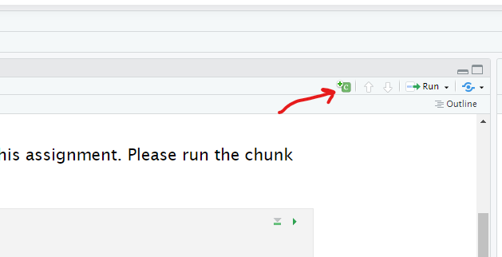

Screenshot of R Code Chunk Button

You may use the esquisse package for your data visualizations (if you wish).

**Task 1:** How many rows and columns are there in the dataset?

### There are 118 rows and 5 columns.

**Task 2:** Examine the structure of the dataset and then convert the “Condition” variable to a factor.

```r
sales = sales %>% mutate(Condition = as_factor(Condition))
```

```r
summary(sales)
```

```
    Mileage            Age           Horsepower    Condition   SalePrice
 Min.   :    51   Min.   : 0.000   Min.   :100.0   New :27   Min.   :  690
 1st Qu.:  3640   1st Qu.: 1.000   1st Qu.:182.5   Used:91   1st Qu.: 6705
 Median : 41608   Median : 7.000   Median :311.0             Median :11105
 Mean   : 51199   Mean   : 6.627   Mean   :292.4             Mean   :12515
 3rd Qu.: 88393   3rd Qu.:11.000   3rd Qu.:393.8             3rd Qu.:18688
 Max.   :147038   Max.   :15.000   Max.   :493.0             Max.   :29600
```

```r
str(sales)
```

```
tibble [118 × 5] (S3: tbl_df/tbl/data.frame)
 $ Mileage   : num [1:118] 980 51 939 60990 467 ...
 $ Age       : num [1:118] 1 0 0 9 0 8 7 1 4 1 ...
 $ Horsepower: num [1:118] 479 477 116 358 314 488 242 147 409 374 ...
 $ Condition : Factor w/ 2 levels "New","Used": 1 1 1 2 1 2 2 2 2 1 ...
 $ SalePrice : num [1:118] 28820 29040 21860 6060 27060 ...
```

**Task 3**: The “SalePrice” variable will be our response variable in our linear regression models. Develop appropriate plots of each of the other four variables versus “SalePrice”.

Each plot should be accompanied by a short comment on the relationship between the variable the “SalePrice”.

Do these relationships match your intuition?

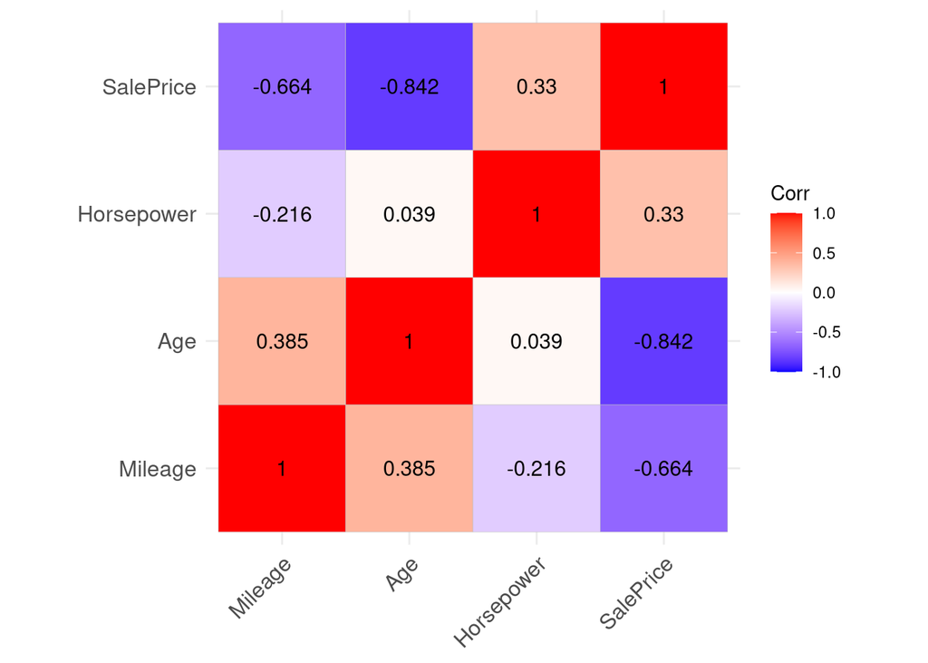

```r
corr = sales %>% select_if(is.numeric) %>% cor(.)
ggcorrplot(corr, lab = TRUE, digits = 3)
```

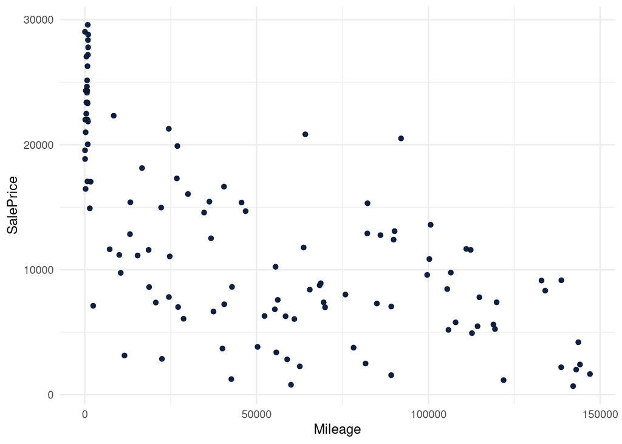

```r
#esquisser()

                                 # Mileage  and Sales Price
library(ggplot2)

ggplot(sales) +
 aes(x = Mileage, y = SalePrice) +
 geom_point(shape = "circle", size = 1.5, colour = "#112446") +
  geom_point(alpha = 0.1) +
 theme_minimal()
```

## The correlation between Mileage and Sales Price is highly correlated. This does match my intuition. As I would have thought, the lower the mileage the higher the sales price.

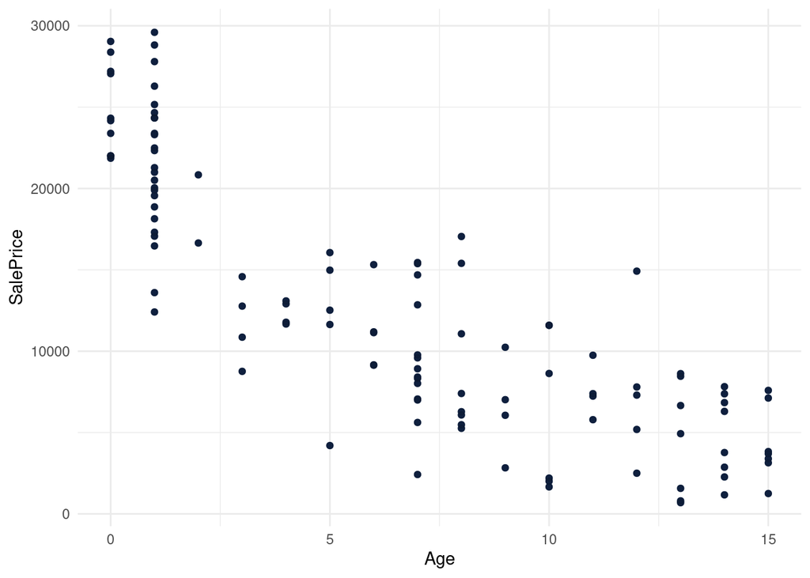

```r
#esquisser()
                                 # Age and Sales Price


library(ggplot2)

ggplot(sales) +
 aes(x = Age, y = SalePrice) +
 geom_point(shape = "circle", size = 1.5, colour = "#112446") +
  geom_point(alpha = 0.1) +
 theme_minimal()
```

## The correlation between Age and Sales Price is highly correlated. This does match my intuition. As the car ages, the sales price goes down.

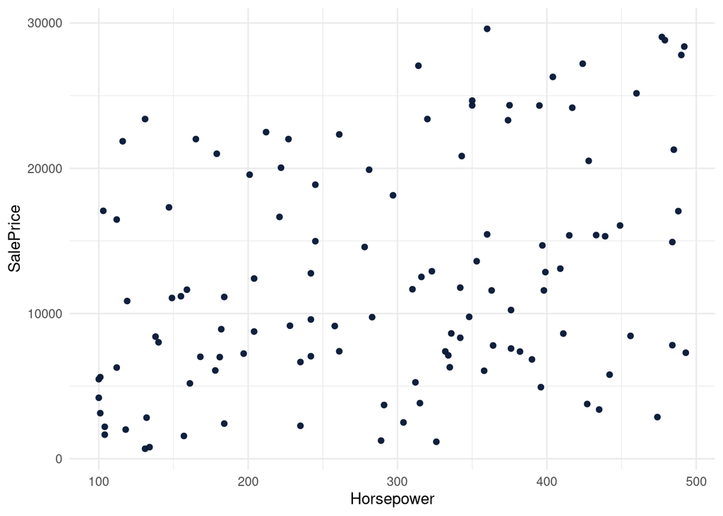

```r
#esquisser()
                                 # Horsepower and Sales Price


library(ggplot2)

ggplot(sales) +
 aes(x = Horsepower, y = SalePrice) +
 geom_point(shape = "circle", size = 1.5, colour = "#112446") +
  geom_point(alpha = 0.1) +
 theme_minimal()
```

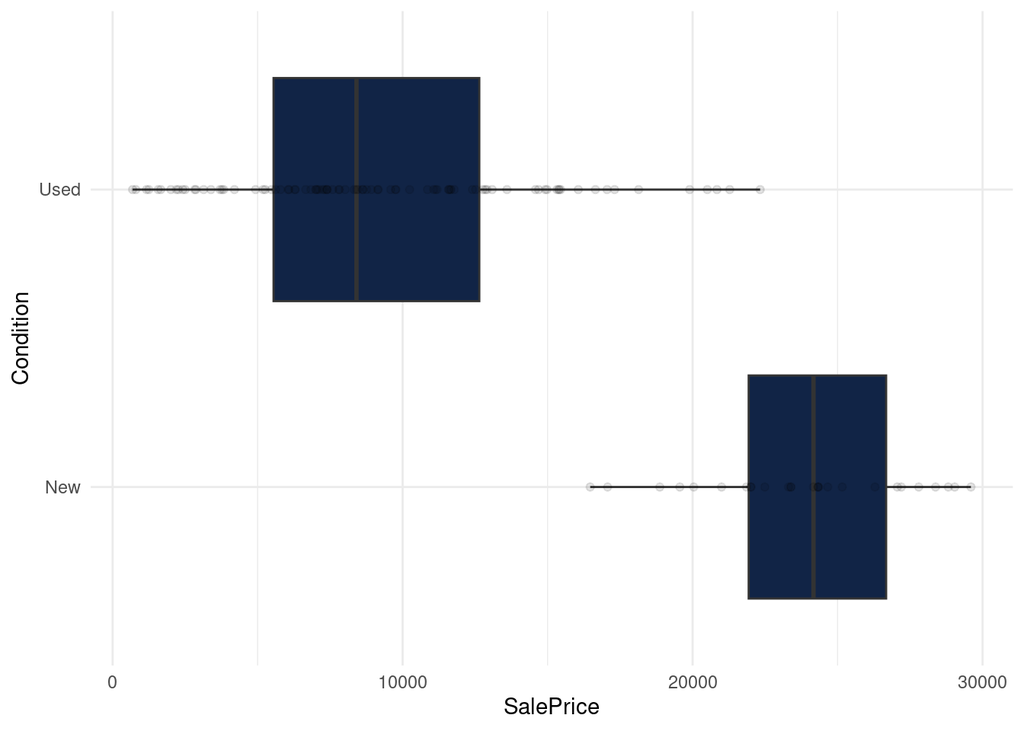

```r
#esquisser()
                                 # Sales Price and Condition

library(ggplot2)

ggplot(sales) +
  aes(x = SalePrice, y = Condition) +
  geom_boxplot(fill = "#112446") +
  geom_point(alpha = 0.1) +
  theme_minimal()
```

```r
#The plot below offers another axis view, if desired

#library(ggplot2)

#ggplot(sales) +
  #aes(x = Condition, y = SalePrice) +
  #geom_boxplot(fill = "#112446") +
  #geom_point(alpha = 0.1) +
  #theme_minimal()
```

## The correlation between Sales Price and Condition is correlated. This does match my intuition. Newer cars have higher sales price. Older/used cars have a lower sales price. These sales prices are in correlation with each other, new or old/used.

**Task 4**: Create a correlation plot for the numeric variables. Hint: You will need to exclude one of the variables as it is not numeric.

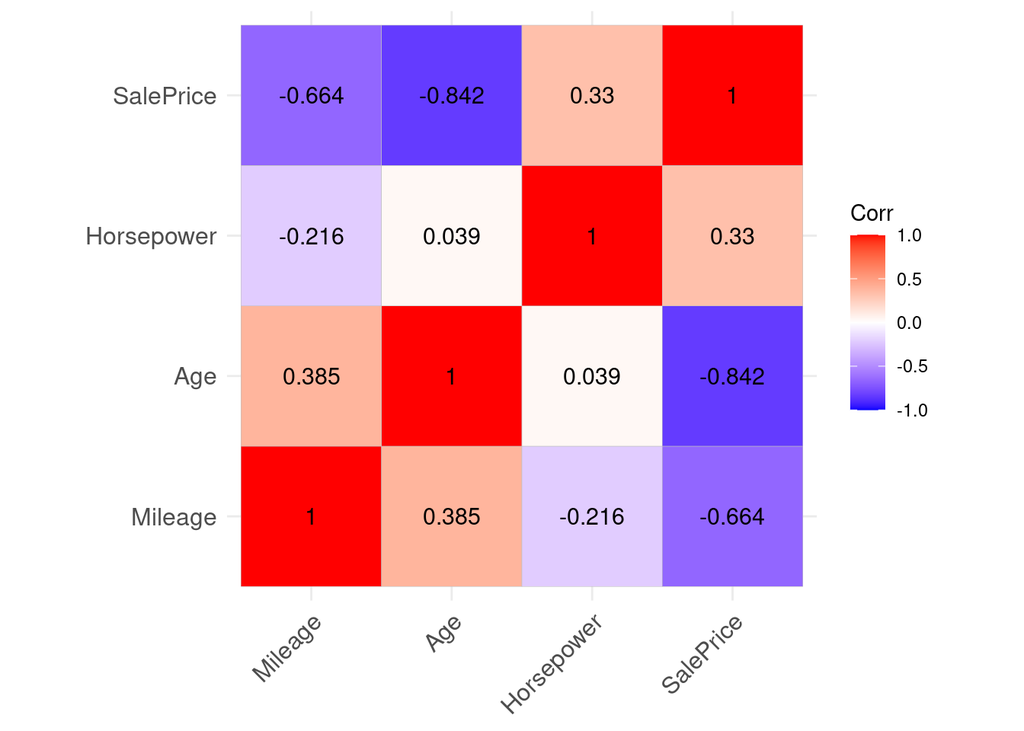

```r
corr = sales %>% select_if(is.numeric) %>% cor(.)
ggcorrplot(corr, lab = TRUE, digits = 3)
```

Which variable is most strongly correlated with SalePrice? Which is most weakly correlated?

**Task 5**: Build a linear regression model with the strongest variable (identified in Task 4). Comment on the quality of the model.

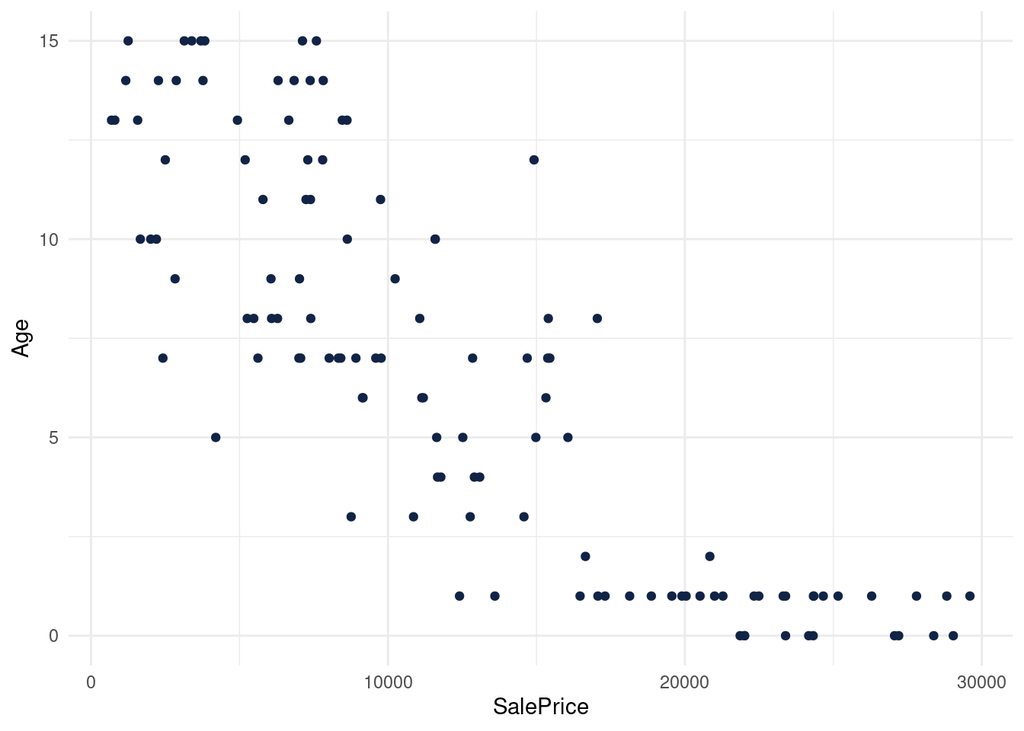

```r
ggplot(sales) +
  aes(x = SalePrice, y = Age) +
  geom_point(shape = "circle", size = 1.5, colour = "#112446") +
  theme_minimal()
```

## The quality of this model is not ideal but does display a negative slope. Furthermore, it appears certain cars or model of cars are immune to drop in saleprice. Thus, without the handful of outliers - we do see a liner model (in the negative direction)>

**Task 6**: Build a linear regression model with the weakest variable (identified in Task 4). Comment on the quality of the model.

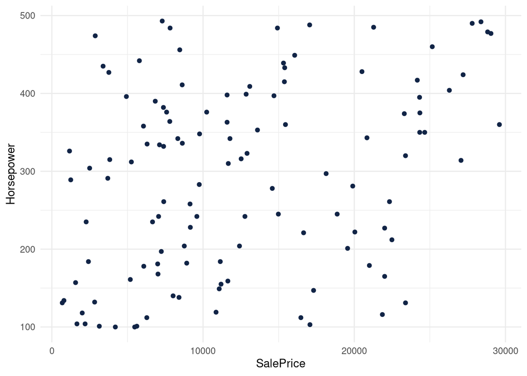

```r
ggplot(sales) +
  aes(x = SalePrice, y = Horsepower) +
  geom_point(shape = "circle", size = 1.5, colour = "#112446") +
  theme_minimal()
```

**Task 7**: Build a linear regression model with the Condition variable as the predictor (use only Condition, no other predictor variables). Comment on the quality of the model.

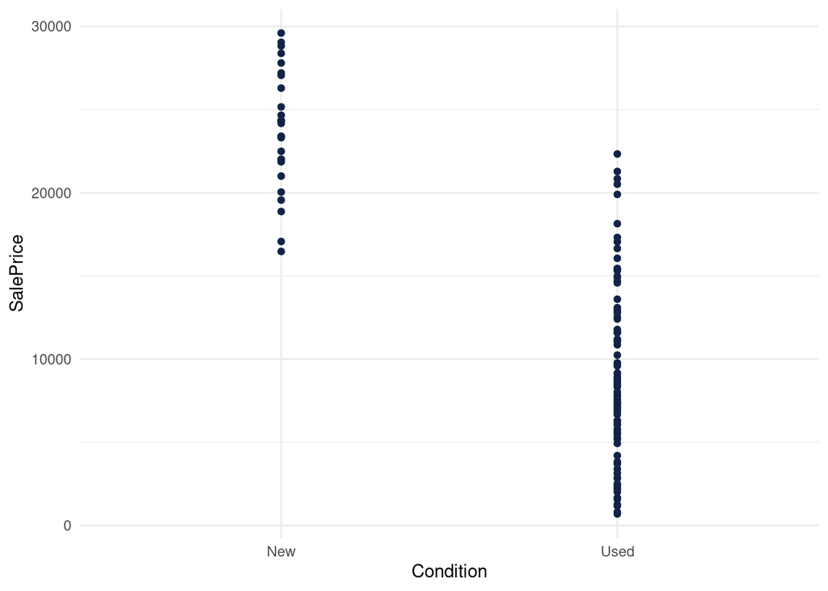

```r
ggplot(sales) +
  aes(x = Condition, y = SalePrice) +
  geom_point(shape = "circle", size = 1.5, colour = "#112446") +
  theme_minimal()
```

## Based on this model, there is a linear trend but not linear regression. There appear to be a floor of low prices that all new cars do not drop down to. The new cars do not appear to have a ceiling. In contrast, the used cars do not appear to have a floor but do have a price ceiling.

## There is a little bit of price overlap for the highest priced used cars and the lowest priced new cars.

## Overall, the quality of the model is clean and crisp but does not answer our question about linera regression.

**Task 8:** Create a model with all variables as predictors of SalePrice. Comment on the quality of the model. Note: Your results may be displayed in scientific notation. This is OK. Adding the code: options(scipen = 999) in the line above your model code will suppress scientific notation (if desired).

```r
#esquisser()

#library(ggplot2)

#ggplot(sales) +
  #aes(x = SalePrice, y = Age + Mileage + Horsepower + Condition) +
    #geom_point(alpha = 0.1)
  #geom_point(shape = "circle", size = 1.5, colour = "#112446") +
  #theme_minimal()
```

```r
options(scipen = 999)


model1 <- lm(SalePrice ~ Age + Mileage + Horsepower + Condition, data = sales)

summary(model1)
```

```
Call:
lm(formula = SalePrice ~ Age + Mileage + Horsepower + Condition,
    data = sales)

Residuals:
    Min      1Q  Median      3Q     Max
-6038.0 -1277.8   114.8  1239.0  5253.6

Coefficients:
                  Estimate   Std. Error t value             Pr(>|t|)
(Intercept)   18593.278530   619.202301  30.028 < 0.0000000000000002 ***
Age            -997.412221    49.072123 -20.325 < 0.0000000000000002 ***
Mileage          -0.041019     0.005088  -8.062    0.000000000000865 ***
Horsepower       18.849507     1.578944  11.938 < 0.0000000000000002 ***
ConditionUsed -3735.159467   665.180005  -5.615    0.000000142406782 ***
---
Signif. codes:  0 '***' 0.001 '**' 0.01 '*' 0.05 '.' 0.1 ' ' 1

Residual standard error: 1976 on 113 degrees of freedom
Multiple R-squared:  0.9395,    Adjusted R-squared:  0.9373
F-statistic: 438.3 on 4 and 113 DF,  p-value: < 0.00000000000000022
```

## 0.9395 is the Rsquared value

## 0.9373 is the Adjusted Rsquared value

## Based on metrics alone, this is a strong model.

(Note: this is a strong model but I do not find it as useful as other models generated. Just because the model is good or clean does not make it relevant or useful).

**DELIVERABLE:** Your deliverable is an HTML document of your work. Render this Quarto file into an HTML document and upload in the appropriate location on Canvas.